# Tutorial 5 - Random Variables and Probability Distributions

Author: Matthew J. Crossley

Last update: 20 May, 2025

## Learning objective

- You have just handed in homework 1 which involved heaps of simple data wrangling and ggplotting so we will take a short break from this and focus on the theory of random variables and probability distributions.
- You should aim to grapple with the practice problems below but be sure to first inspect the upcoming quiz so that you can appropriately allocate your time and attention.

## Work through these practice exercises (1)

- It’s a good idea to work through these on your own, but if you get very stuck, solutions can be found here

### 1.

Consider an experiment in which two four-sided die are thrown.

**(a)** Create a `data.table` named `ans_1a` with two columns labelled `die1` and `die2` where these columns encode the **sample space** of this experiment. As a hint, the following shows the what the output of `ans_1a[1:8]` should produce for you. It’s up to you to determine how many observations in total `ans_1a` should have.

```
##     die1  die2
##    <num> <num>
## 1:     1     1
## 2:     2     1
## 3:     3     1
## 4:     4     1
## 5:     1     2
## 6:     2     2
## 7:     3     2
## 8:     4     2
```

**(b)** Create a deep copy of `ans_1a` called `ans_1b` and then add a column to `ans_1b` called `X` and set it equal to the sum of the corresponding `die1` and `die2` values on a per row basis.

**(c)** Let $X$ be the random variable defined by the `X` column in `ans_1b`. What is $P(X<5)$? Store your result in a variable named `ans_1c`.

**(d)** Is the event defined as the set of all outcomes for which $X=2$ an elementary event? Store your answer (`"YES"` or `"NO"`) in a variable named `ans_1d`.

### 2.

For the following probability distribution:

| $x$ | 2 | 3 | 4 | 5 | 6 |
| --- | --- | --- | --- | --- | --- |
| $f(x)$ | .1 | .3 | .3 | .2 | .1 |

**(a)** Is $f(x)$ a valid probability distribution? Store your answer (`"YES"` or `"NO"`) in a variable named `ans_2a`.

**(b)** Calculate $E(X)$ store the result in a variable named `ans_2b`.

**(c)** Calculate $P(X \geq 4)$ store the result in a variable named `ans_2c`.

**(d)** Calculate $P(2 < X \leq 4)$ and store the result in a variable named `ans_2d`.

### 3.

Given the following probability distribution:

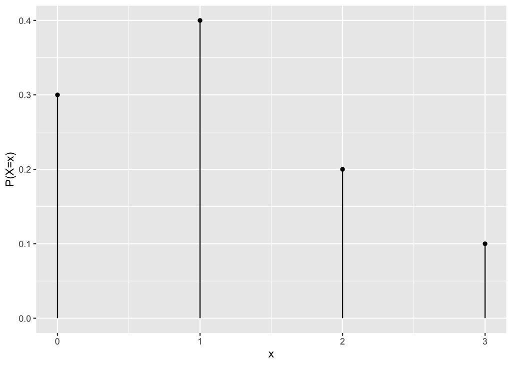

Find:

**(a)** Calculate $P(X \geq 2)$ and store your result in a variable named `ans_3a`.

**(b)** Calculate $P(0 < X \leq 2)$ and store your result in a variable named `ans_3b`.

**(c)** Calculate $E(X)$ and store your result in a variable named `ans_3c`.

**(d)** $Var(X)$ and store your result in a variable named `ans_3d`.

**(e)** $sd(X)$ and store your result in a variable named `ans_3e`.

### 4.

Consider the probability distributions for random vairbale $X$ and random variable $Y$ defined below.

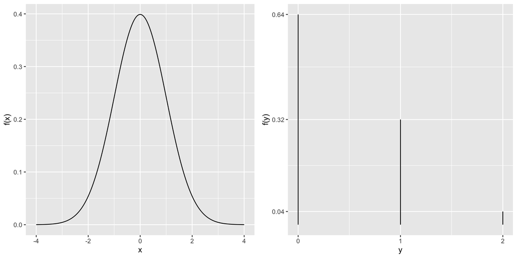

**a.** What is the population mean of $X$? Store your answer in a variable named `ans_4a`.

**b.** What is the population mean of $Y$? Sore your answer in a variable named `ans_4b`.

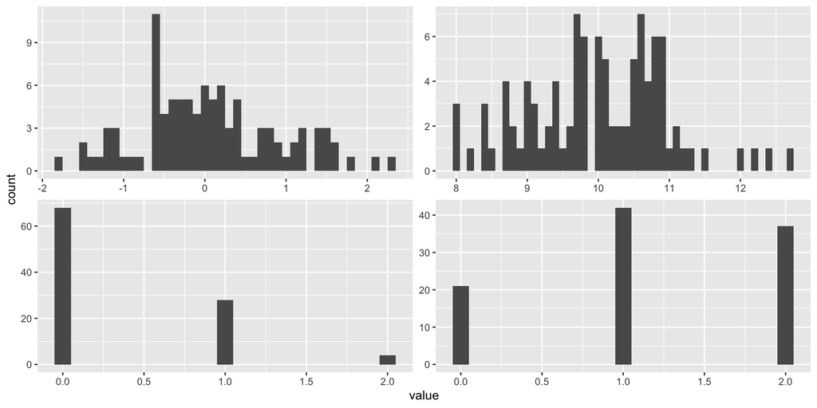

**c.** Which of the histograms above most likely corresponds to a sample from $X$? Please store your answer as one of the following:

- `ans_4c <- 'upper left'`
- `ans_4c <- 'lower left'`
- `ans_4c <- 'upper right'`
- `ans_4c <- 'lower right'`

**d.** Which of the histograms above most likely corresponds to a sample from $Y$? Please store your answer as one of the following:

- `ans_4d <- 'upper left'`
- `ans_4d <- 'lower left'`
- `ans_4d <- 'upper right'`
- `ans_4d <- 'lower right'`

## Work through these practice exercises (2)

- It’s a good idea to work through these on your own, but if you get very stuck, solutions can be found here

### 1.

Consider the following two random variables:

- $X\sim\mathcal{N}(\mu=0,\sigma=1)$
- $Y{\sim}Binom(n=10,p=0.2)$

The $X$ probability distribution (pdf since $X$ is continuous) and the $Y$ probability distribution (pmf since $Y$ is discrete) are illustrated below. The probability corresponding to $x{\leq}1$ and $y{\leq}3$ (`lower.tail=TRUE`) are coloured blue and the the probability corresponding to $x{>}1$ and $y{>}3$ (`lower.tail=FALSE`) are coloured green. This figure is only here to help you think about what is being asked below.

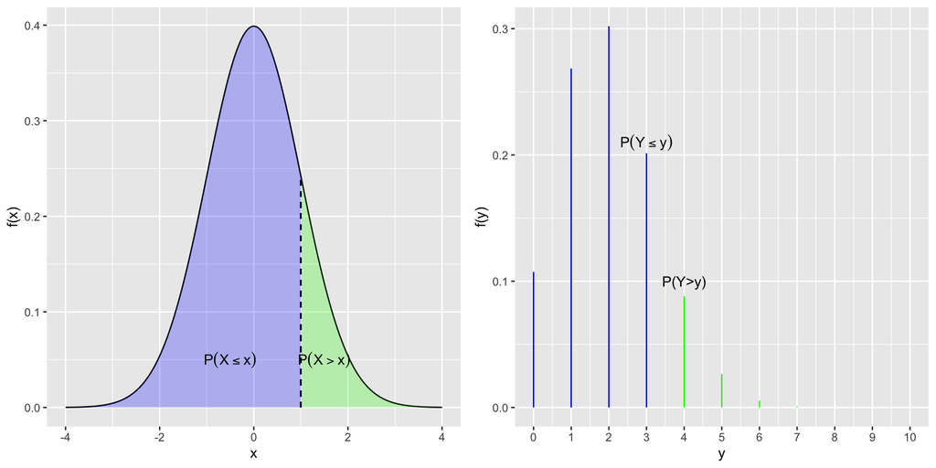

Are the following statements `TRUE` or `FALSE`?

**(a)** $p(X{<}x)=p(X{\leq}x)$ for all $x$.

```r
# uncomment the correct answer
# ans_1a <- TRUE
# ans_1a <- FALSE
```

**(b)** $p(Y < y) = p(Y\leq y)$ for all $y$.

```r
# uncomment the correct answer
# ans_1b <- TRUE
# ans_1b <- FALSE
```

**(c)** $p(X < x) = 1 - p(X > x)$ for all $x$.

```r
# uncomment the correct answer
# ans_1c <- TRUE
# ans_1c <- FALSE
```

**(d)** $p(Y < y) = 1 - p(Y > y)$ for all $y$.

```r
# uncomment the correct answer
# ans_1d <- TRUE
# ans_1d <- FALSE
```

### 2.

Consider the following random variables:

- $X{\sim}\mathcal{N}(\mu_X=15,\sigma_X=2.74)$
- $Y{\sim}Binom(n=30,p=0.5)$.

The $X$ and $Y$ distributions are illustrated in the following figure:

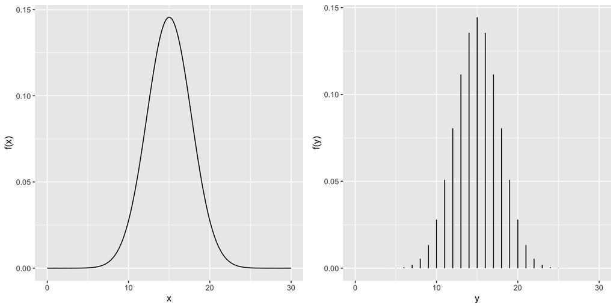

For all of the following use built-in `R` functions to compute the requested quantities. The functions are covered in the lecture notes this week.

**(a)** Compute $P(X > 17)$ and store it in a variable named `ans_2a`.

**(b)** Compute $P(X \leq 14)$ and store it in a variable named `ans_2b`.

**(c)** Compute $P(X \geq 20)$ and store it in a variable named `ans_2c`.

**(d)** Compute $P(X < 13)$ and store it in a variable named `ans_2d`.

**(e)** Compute $P(Y > 17)$ and store it in a variable named `ans_2e`.

**(f)** Compute $P(Y \leq 14)$ and store it in a variable named `ans_2f`.

**(g)** Compute $P(Y \geq 20)$ and store it in a variable named `ans_2g`.

**(h)** Compute $P(Y < 13)$ and store it in a variable named `ans_2h`.

**(i)** How do all of the above quantities computed with respect to $X$ compare to those computed with respect to $Y$? No points for this one. Just think about it.

### 3.

Consider the following plots:

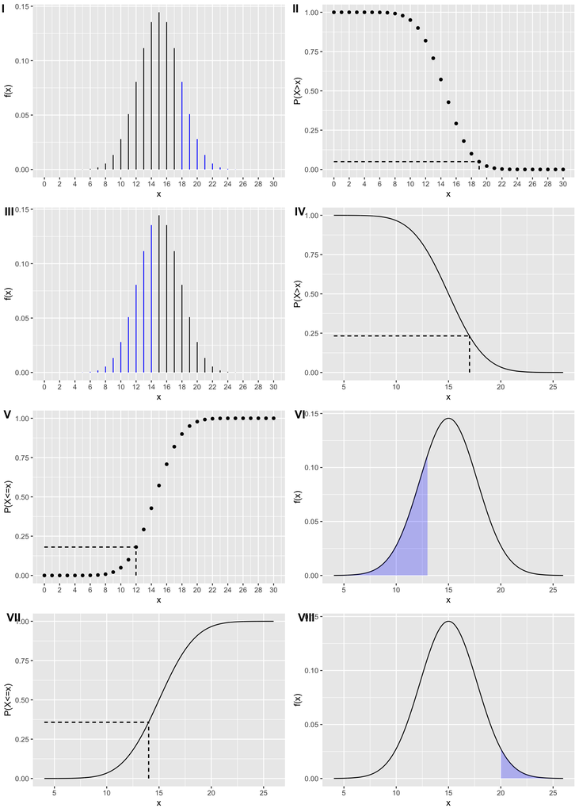

For each of the following problems, please respond by setting the appropriate variable to one of `"I"`, `"II"`, `"III"`, `"IV"`, `"V"`, `"VI"`, `"VII"`, or `"VIII"`. When responding to the questions below, please note that the x and y axis labels in the above plots all use ‘X’ or ‘x’ but may correspond to either the X or the Y random variable from problem 2.

**(a)** Which plot corresponds to the quantity requested in problem 2a? Please store your answer in a variable named `ans_3a`.

**(b)** Which plot corresponds to the quantity requested in problem 2b? Please store your answer in a variable named `ans_3b`.

**(c)** Which plot corresponds to the quantity requested in problem 2c? Please store your answer in a variable named `ans_3c`.

**(d)** Which plot corresponds to the quantity requested in problem 2d? Please store your answer in a variable named `ans_3d`.

**(e)** Which plot corresponds to the quantity requested in problem 2e? Please store your answer in a variable named `ans_3e`.

**(f)** Which plot corresponds to the quantity requested in problem 2f? Please store your answer in a variable named `ans_3f`.

**(g)** Which plot corresponds to the quantity requested in problem 2g? Please store your answer in a variable named `ans_3g`.

**(h)** Which plot corresponds to the quantity requested in problem 2h? Please store your answer in a variable named `ans_3h`.

### 4.

Consider the random variable $X{\sim}F(d_1,d_2)$ with fixed parameters $d_1=5$, $d_2=100$. Given these values of $d_1$ and $d_2$, the following holds true:

$$\text{if } X \sim F(d_1,d_2)\text{ then:}\\
\mathbb{E}[X] = \frac{d_2}{d_2 - 2} \\
\mathbb{V}\text{ar}[X] = \frac{2 d_2^2 (d_1 + d_2 - 2)}{d_1 (d_2 - 2)^2
(d_2 - 4)}$$

You might need numerical values for $\mathbb{E}[X]$ and $\mathbb{V}\text{ar}[X]$ later in this problem. If you do, you can compute them with the following code chunk:

```r
d1 <- 5
d2 <- 100

mu_x <- (d2/(d2-2))
sig_x <- (2*(d2^2)*(d1+d2-2))/(d1*(d2-2)^2*(d2-4))
```

We next perform 6 experiments. In each experiment, we draw 1000 samples from $X$ and plot a histogram for the results of each experiment. The results of these experiments are shown in the following histograms.

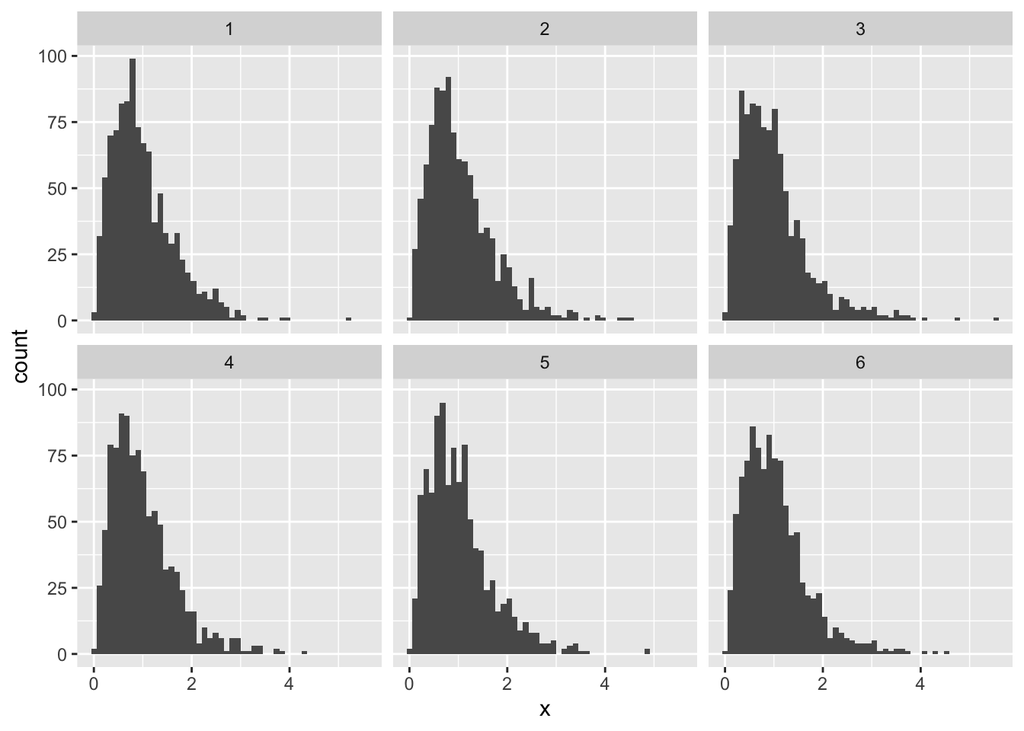

**(a)**Do the histograms appear Normally distributed? If not, what is the main difference? Please respond with one of the following:

- `ans_4a <- "Skewed"`
- `ans_4a <- "Normal"`

We next estimate the distribution of sample means as a function of the number of samples `n` that were drawn per experiment. We will perform 6 experiments in which we draw 2, 5, 10, 15, 30, and 50 samples from $X$ (each of these numbers corresponds to one experiment). Each of these experiments, if performed once, will give us one sample mean. To examine the distribution of sample means, we repeat each experiment 1000 times. This will give us 1000 sample means per experiment. For each experiment, we estimate the distribution of sample means with a histogram and make a single figure with separate panels for each experiment to show our results.

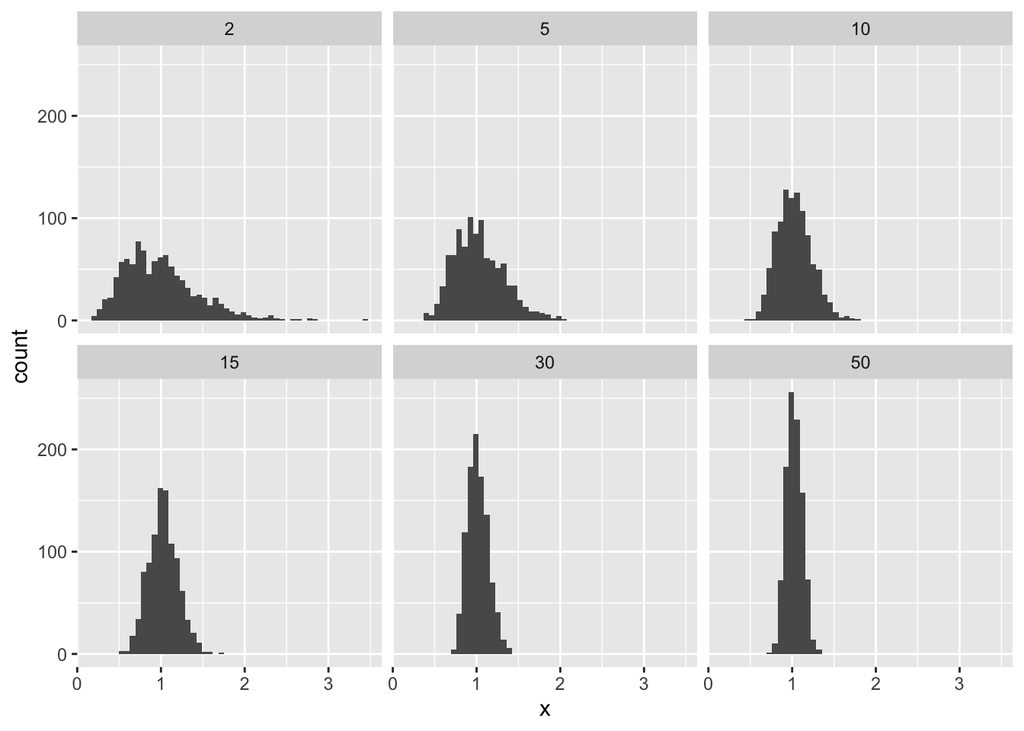

**(b)** What happens to the variance of the distribution of sample means as $n$ increases?

- `ans_4b <- "Stays the same"`
- `ans_4b <- "Increases"`
- `ans_4b <- "Decreases"`

**(c)** What happens to the skew of the distribution of sample means as $n$ increases?

- `ans_4c <- "Stays the same"`
- `ans_4c <- "Increases"`
- `ans_4c <- "Decreases"`

**(d)** If $X{\sim}F(d_1,d_2)$ as defined at the top of the problem, and $n=1000$, what is the population mean of $\bar{X}$ (the distribution of sample means)? Store your answer in a variable named `ans_4d`.

**(e)** If $X{\sim}F(d_1,d_2)$ as defined at the top of the problem, and $n=1000$, what is the population variance of $\bar{X}$ (the distribution of sample means)? Store your answer in a variable named `ans_4e`.